# Tarea 5 HIVE

Mariana Godina Abasolo

### Foto de tu clúster de AWS

- management console

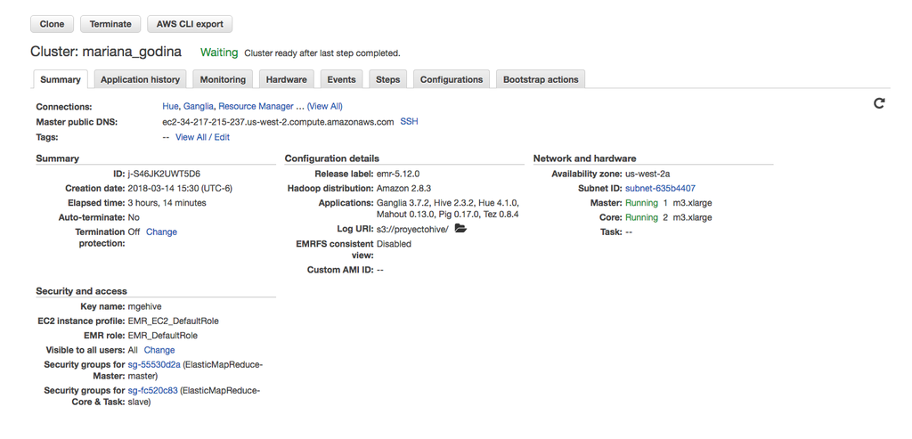

### Ejercicio 1

1. ¿Cuántos “jefes” hay en la tabla empleados?
- Hay 2 “jefes”

[figure not shown]

| _c0 |
| --- |
| 2 |

¿Cuáles son estos jefes: número de empleado, nombre, apellido, título, fecha de nacimiento, fecha en que iniciaron en la empresa, ciudad y país? (atributo reportsto, ocupa explode en tu respuesta)

[figure not shown]

| employeeid | firstname | lastname | title | birthdate | hiredate | city | country |
| --- | --- | --- | --- | --- | --- | --- | --- |
| 2 | Andrew | Fuller | "Vice President | NULL | 1952-02-19 | 908 W. Capital Way | 98401 |
| 5 | Steven | Buchanan | Sales Manager | 1955-03-04 | 1993-10-17 | London | UK |

2. ¿Quién es el segundo “mejor” empleado que más órdenes ha generado? (nombre, apellido, título, cuándo entró a la compañía, número de órdenes generadas, número de órdenes generadas por el mejor empleado (número 1))
- La segunda “mejor” empleada es Janet con 127 ordenes generadas.

[figure not shown]

| employeeid | n | n_top1 | firstname | lastname | title | hiredate |
| --- | --- | --- | --- | --- | --- | --- |
| 3 | 127 | 156 | Janet | Leverling | Sales Representative | 1992-04-01 |

3. ¿Cuál es el delta de tiempo más grande entre una orden y otra?
- 3 días es el tiempo más grande entre una orden y otra

[figure not shown]

| delta |
| --- |
| 3 |

### Ejercicio 2

1. ¿Qué aerolíneas (nombres) llegan al aeropuerto “Honolulu International Airport”?

[figure not shown]

| codigo | aerolinea |
| --- | --- |
| HA | Hawaiian Airlines Inc. |
| AA | American Airlines Inc. |
| AS | Alaska Airlines Inc. |
| US | US Airways Inc. |
| UA | United Air Lines Inc. |
| VX | Virgin America |
| DL | Delta Air Lines Inc. |

2. ¿En qué horario (hora del día, no importan los minutos) hay salidas del aeropuerto de San Francisco (“SFO”) a “Honolulu International Airport”?

[figure not shown]

| hora | origin_airport | destination_airport |
| --- | --- | --- |
| NULL | SFO | HNL |
| 1 | SFO | HNL |
| 6 | SFO | HNL |
| 7 | SFO | HNL |
| 8 | SFO | HNL |
| 9 | SFO | HNL |
| 10 | SFO | HNL |
| 11 | SFO | HNL |
| 12 | SFO | HNL |
| 13 | SFO | HNL |

[output cut: 10 more lines]

3. ¿Qué día de la semana y en qué aerolínea nos conviene viajar a “Honolulu International Airport” para tener el menor retraso posible?
- El día de la semana que nos conviene viajar a “Honolulu International Airport” es el Martes por la aerolínea Alska Airlines Inc.

[figure not shown]

```r
read_csv("Ejercicio2/query-hive-108.csv")
```

| dia_semana | aerolinea | retraso_promedio |
| --- | --- | --- |
| 3 | Alaska Airlines Inc. | 23.96749 |

4. ¿Cuál es el aeropuerto con mayor tráfico de entrada?
- El aeropuerto con mayor tráfico es el de atlanta

[figure not shown]

```r
read_csv("Ejercicio2/query-hive-133.csv")
```

| codigo | aeropuerto | n |
| --- | --- | --- |
| ATL | Hartsfield-Jackson Atlanta International Airport | 346904 |

[figure not shown]

```r
read_csv("Ejercicio2/query-hive-225.csv")
```

| dia_semana | codigo | aerolinea | promedio_retraso |
| --- | --- | --- | --- |
| 1 | NK | Spirit Air Lines | 18.79563 |
| 2 | NK | Spirit Air Lines | 15.71466 |
| 3 | UA | United Air Lines Inc. | 14.28220 |
| 4 | UA | United Air Lines Inc. | 14.88743 |
| 5 | NK | Spirit Air Lines | 15.78610 |
| 6 | NK | Spirit Air Lines | 15.78030 |
| 7 | NK | Spirit Air Lines | 17.14920 |

6. ¿Cuál es la tercer aerolínea con menor retraso de salida los lunes (day of week = 2)?
- La tercer aerolínea con menor retraso es Southwest Airlines Co.

[figure not shown]

```r
read_csv("Ejercicio2/query-hive-179.csv")
```

| codigo | aerolinea | prom_retraso |
| --- | --- | --- |
| WN | Southwest Airlines Co. | 23.81846 |

[figure not shown]

```r
read_csv("Ejercicio2/query-hive-188.csv")
```

| codigo | aeropuerto | num_destinos |
| --- | --- | --- |
| ATL | Hartsfield-Jackson Atlanta International Airport | 169 |